# Function on Scalar Regression under Complex Survey Settings

Lily Koffman

UVA School of Data Science

# Motivation: functional data in large epidemiological studies

## National Health and Nutrition Examination Survey (NHANES)

[figure not shown]

## NHANES

[figure not shown]

## NHANES: functional data

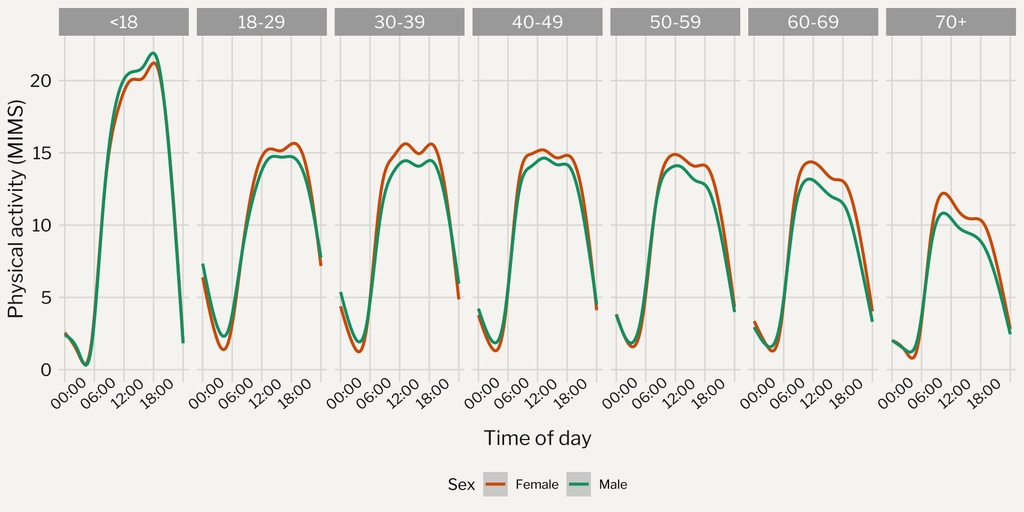

## NHANES: function on scalar regression (FoSR)

Model:
$$\mathbb{E}[\mathrm{PA}_i(s)] = \beta_0(s) + \beta_1(s)\mathbb{I}\{\mathrm{sex}_i=\mathrm{female}\} + \sum_{k=2}^{7}\beta_k(s)\mathbb{I}\{\mathrm{agecat}_i=k\}$$

$i$: participant;

$s \in \{1, \dots, 1440\}$: each minute of the day

## FoSR: model fitting

- Fast univariate inference (FUI) (Cui et al. 2021)
- Fit separate (univariate) GLM at each point $s$, smooth the resulting point estimates
- Bootstrap subjects to get confidence bands

# Gap: no method to adjust for survey design

## NHANES is not a random sample!

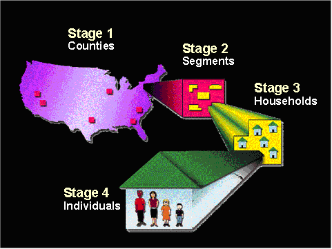

Individuals sampled in geographic clusters, minority groups oversampled

Are estimates from FoSR valid for population-level inference?

[NHANES Sample Design Tutorial](https://wwwn.cdc.gov/nchs/nhanes/tutorials/sampledesign.aspx)

# Idea: combine a bunch of existing methods

## Survey function on scalar regression

- **No** method exists for function on scalar regression under complex surveys
- Standard regression: well developed methods and software to take into accounts weights and correlation between clusters (e.g. $\texttt{svyglm}$, $\texttt{svycoxph}$) (Lumley 2010) for estimation and inference
- FUI built on separate GLMS
- **Idea**: incorporate survey weights into the GLMs (estimation) and use survey-aware replication/bootstrap methods for inference

# Easy enough to implement – but how do we know if it works?

## Simulation goal

- Generate a superpopulation of individuals who belong to a stratum and cluster
- Each individual has functional outcome and covariate
- [Optionally] create correlation in functional outcomes within strata and clusters
- [Optionally] create heterogeneity in covariate effects by strata/cluster
- Sample from the superpopulation in each iteration of the simulation
  - [Optionally] allow for informative sampling: probability of being included in sample related to functional outcome

## Data generating

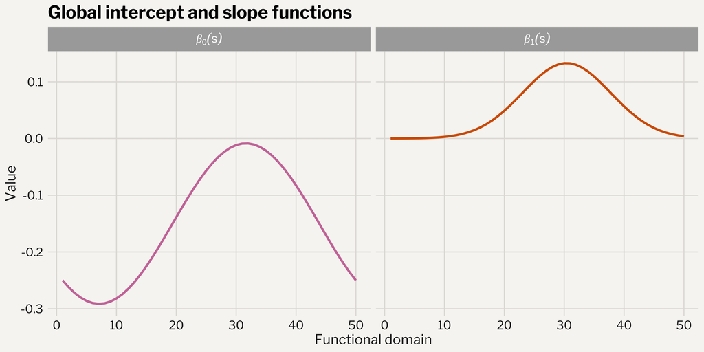

## Data generating: add stratum-specific covariate effects

$\beta_{1(h)}(s) = \gamma_h\cdot\beta_1(s)$

Where $\gamma_h \sim N(1, 0.125^2)$

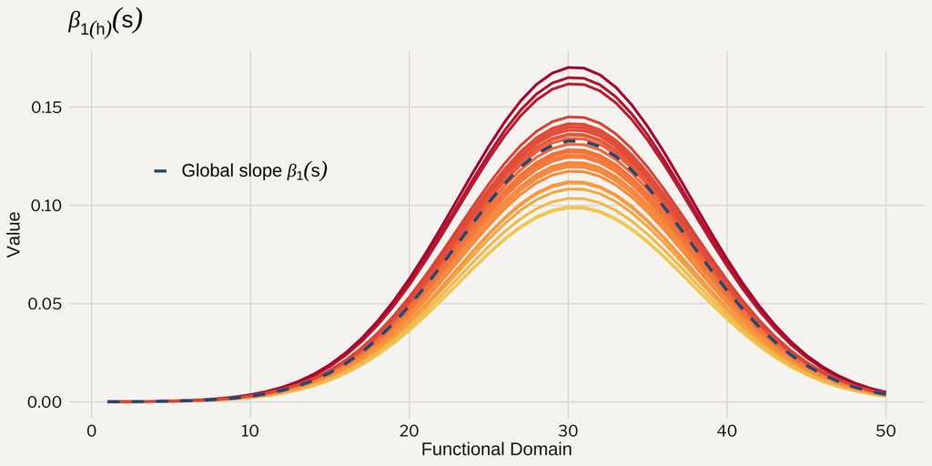

## Data generating: induce strata and cluster-level correlation with functional random effects

Generate strata-level ($b_{h(i)}(s)$) and cluster-level ($b_{c(h, i)}(s)$) random effects using B-spline basis

Individual-level linear predictor: $\eta_i(s) = \beta_0(s) + X_i\beta_{1(h)}(s) + b_{h(i)}(s) + b_{c(h, i)}(s)$

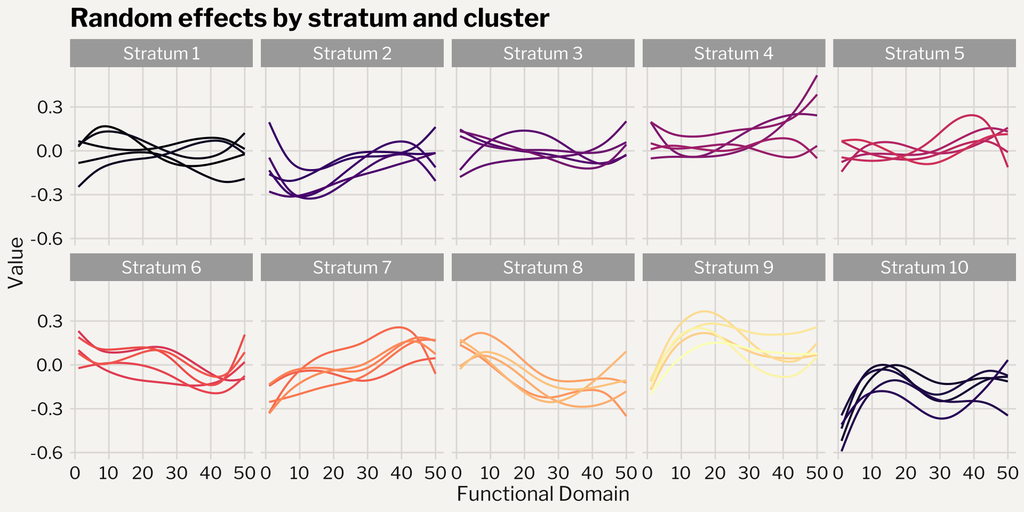

## Data generating: induce strata and cluster-level correlation with functional random effects

Generate strata-level ($b_{h(i)}(s)$) and cluster-level ($b_{c(h, i)}(s)$) random effects using B-spline basis

Individual-level linear predictor: $\eta_i(s) = \beta_0(s) + X_i\beta_{1(h)}(s) + b_{h(i)}(s) + b_{c(h, i)}(s)$

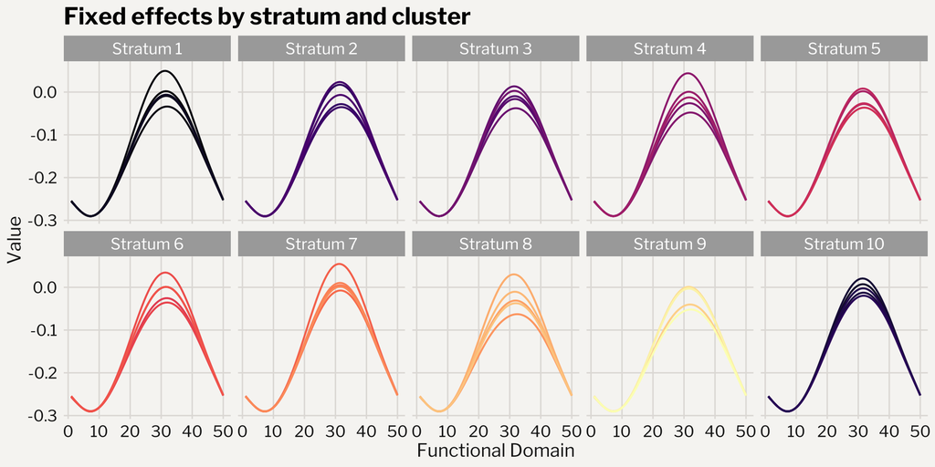

## Data generating: induce strata and cluster-level correlation with functional random effects

Generate strata-level ($b_{h(i)}(s)$) and cluster-level ($b_{c(h, i)}(s)$) random effects using B-spline basis

Individual-level linear predictor: $\eta_i(s) = \beta_0(s) + X_i\beta_{1(h)}(s) + b_{h(i)}(s) + b_{c(h, i)}(s)$

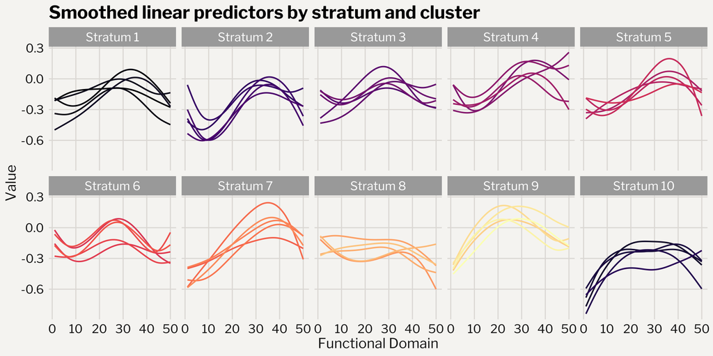

## Data generating: get functional outcomes from linear predictors

$Y_i(s)$ sampled from $\mathcal{N}(\eta_i(s), \sigma^2)$

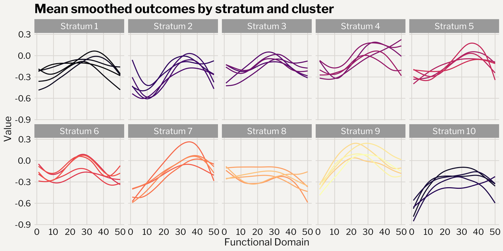

## Survey sampling: sample individuals from superpopulation

1. Sample 2 clusters from each stratum
2. Sample individuals from each cluster
3. Informative sampling: allow selection probability to depend on functional outcome: $\pi_i \propto \frac{1}{L}\sum_{s=1}^LY_i(s)$

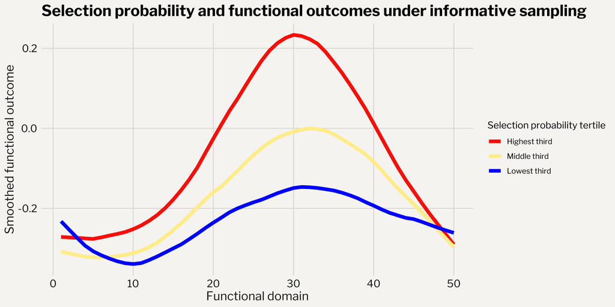

## Survey sampling: sample individuals from superpopulation

1. Sample 2 clusters from each stratum
2. Sample individuals from each cluster
3. Informative sampling: allow selection probability to depend on functional outcome: $\pi_i \propto \frac{1}{L}\sum_{s=1}^LY_i(s)$

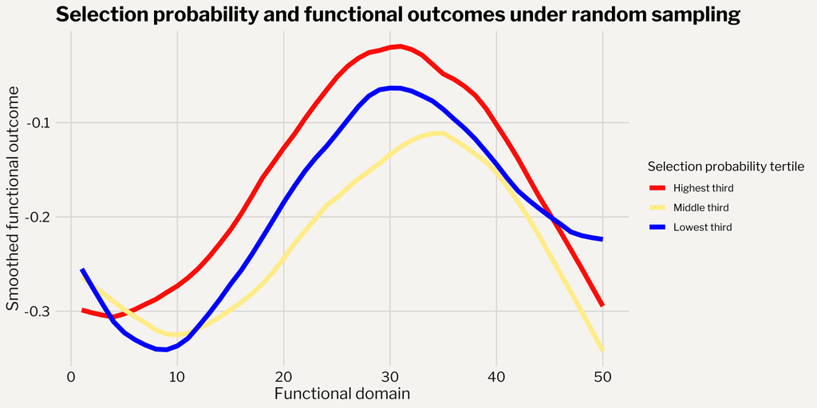

## Computational considerations

## Next steps

Cui, Erjia, Andrew Leroux, Ekaterina Smirnova, and Ciprian M. Crainiceanu. 2021. “Fast Univariate Inference for Longitudinal Functional Models.” *Journal of Computational and Graphical Statistics* 31 (1): 219–30. https://doi.org/10.1080/10618600.2021.1950006.

Lumley, Thomas. 2010. *Complex Surveys: A Guide to Analysis Using R: A Guide to Analysis Using R*. John Wiley; Sons.